# Data Open Lecture: An Introduction of R

# Summarize Variables (1): Type and Size

- First identify the type of each variable

```r
data[,lapply(.SD, class)]
```

```
##          n   carat       cut     color   clarity   depth   table   price
## 1: integer numeric character character character numeric numeric integer
##          x       y       z
## 1: numeric numeric numeric
```

- count NA values of each variable

```r
x = data[,price]
nonNA = function(x){
    return(sum(!is.na(x)))
}
nonNA(data[,price])
```

```
## [1] 39708
```

```r
data[,lapply(.SD, nonNA)] # count of non-NA values of variables
```

```
##        n carat   cut color clarity depth table price     x     y     z
## 1: 53940 53940 53940 53940   53940 53940 53940 39708 53940 53940 53940
```

# Summarize Variables (2): Numeric Statistics

- Convert numeric variable into numeric statistics

```r
summary_num = function(x){
    if(class(x) == "character")
        return(NA)
    else
        x_trans = c(mean(x, na.rm = T), sd(x, na.rm = T), quantile(x, na.rm = T))
    return(x_trans)
}
summary_num(data[,price])
```

```
##                            0%       25%       50%       75%      100%
##  3928.360  3992.675   326.000   949.000  2397.000  5302.250 18818.000
```

```r
data[,lapply(.SD, summary_num)]
```

```
##           n     carat cut color clarity     depth     table     price
## 1: 26970.50 0.7979397  NA    NA      NA 61.749405 57.457184  3928.360
## 2: 15571.28 0.4740112  NA    NA      NA  1.432621  2.234491  3992.675
## 3:     1.00 0.2000000  NA    NA      NA 43.000000 43.000000   326.000
## 4: 13485.75 0.4000000  NA    NA      NA 61.000000 56.000000   949.000
## 5: 26970.50 0.7000000  NA    NA      NA 61.800000 57.000000  2397.000
## 6: 40455.25 1.0400000  NA    NA      NA 62.500000 59.000000  5302.250
## 7: 53940.00 5.0100000  NA    NA      NA 79.000000 95.000000 18818.000
##            x         y          z
## 1:  5.731157  5.734526  3.5387338
## 2:  1.121761  1.142135  0.7056988
## 3:  0.000000  0.000000  0.0000000
## 4:  4.710000  4.720000  2.9100000
## 5:  5.700000  5.710000  3.5300000
## 6:  6.540000  6.540000  4.0400000
## 7: 10.740000 58.900000 31.8000000
```

# Summarize Variables (3): Frequency Table

- We create a function to get the most 5 frequent values

```r
summary_value = function(x){
    freq = sort(table(x), decreasing = TRUE)
    return(names(freq)[1:5])
}
data[,lapply(.SD, summary_value)]
```

```
##    n carat       cut color clarity depth table price    x    y    z
## 1: 1   0.3     Ideal     G     SI1    62    56   605 4.37 4.34  2.7
## 2: 2  0.31   Premium     E     VS2  61.9    57   828 4.34 4.37 2.69
## 3: 3  1.01 Very Good     F     SI2  61.8    58   776 4.33 4.35 2.71
## 4: 4   0.7      Good     H     VS1  62.2    59   789 4.38 4.33 2.68
## 5: 5  0.32      Fair     D    VVS2  62.1    55   666 4.32 4.32 2.72
```

- Get the frequency of most 5 frequent values, tail and NA

```r
summary_freq = function(x){
    freq = sort(table(x), decreasing = TRUE)
    return(c(freq[1:5], sum(freq[-(1:5)]), sum(is.na(x))))
}
data[,lapply(.SD, summary_freq)]
```

```
##        n carat   cut color clarity depth table price     x     y     z
## 1:     1  2604 21551 11292   13065  2239  9881   103   448   437   767
## 2:     1  2249 13791  9797   12258  2163  9724    96   437   435   748
## 3:     1  2242 12082  9542    9194  2077  8369    95   429   425   738
## 4:     1  1981  4906  8304    8171  2039  6572    91   428   421   730
## 5:     1  1840  1610  6775    5066  2020  6268    88   425   414   697
## 6: 53935 43024     0  8230    6186 43402 13126 39235 51773 51808 50260
## 7:     0     0     0     0       0     0     0 14232     0     0     0
```

# Summarize Variables (4): Merge

- Use a list to collect these summaries, each reorganized by variable names as index

```r
fL = list(class, nonNA, summary_num, summary_value, summary_freq)
summaryL = list()
for(i in 1:length(fL)){
    summaryL[[i]] = data[,lapply(.SD, fL[[i]])]
    summaryL[[i]] = data.table(t(summaryL[[i]]), keep.rownames=TRUE)
    setkey(summaryL[[i]], rn)
}
```

- Merge a list of data.tables into one data.table with Reduce()

```r
summary_data = Reduce(function(X,Y){X[Y]}, summaryL)
colnames(summary_data) = c("variable", "type", "N",
                                                     "mean", "sd", "min", "Q1", "median", "Q3", "max",
                                                     paste("value", 1:5), paste("freq", c(1:5, "others", "NA")))
write.csv(summary_data, "Rlecture_Diamonds_summary.csv", row.names = FALSE, na = "")
```

# 4.3 Data Cleaning

# Why Data Cleaning

- A key step to prepare big data for machine learning prediction
- Standardize raw data for statistical models to understand:
- For programming generalization: convert data to numeric matrices for general-model use (beyond linear models in R)
- Solve mathematical problems in data: sparsity, outliers, …
- Difficulty: the size and complexity of variables in data

| Variable_Issue | Example | Model_Effect | Test |
| --- | --- | --- | --- |
| Non-numeric | a,b,c,d | Error | Data Type |
| Sparsity | 1,1,1,1 | Noise | Count Frequency |
| Collinearity | 1,2,3,4; 2,4,6,8 | Robust loss | Correlation Matrix |
| Missing values | 1,NA,3,NA | Error | Count NAs |
| Distribution Bias | 1,2,3,1000 | Robust loss | Numeric Statistics |

# Data Cleaning (1): Numeralization

Our Goal: Convert all non-numeric variables into numeric varibles

- Non-numeric variables with prior information (ordinal, time, …) $\rightarrow$ map into numeric values with a key-value data.table

```r
mapDT = data.table(c("Fair", "Good", "Very Good", "Premium", "Ideal"), 1:5, key = "V1")
setkey(data, "cut")
op = data[mapDT]
data[, cut := op[,V2]]
```

- All other non-numeric variables $\rightarrow$ 0-1 dummy variables

```r
options(na.action='na.pass')
data_clean = data.table(model.matrix( ~ . , data = data))
dim(data_clean)
```

```
## [1] 53940    23
```

# Data Cleaning (2): Detect and Delete Sparse Variables

- Check the number of NAs and most frequent values of each variable, define it as sparity

```r
# data_clean[,lapply(.SD, summary_freq)]
sparsity = function(x){
    op = sort(table(x), decreasing = TRUE)[1] + sum(is.na(x))
    return(op/length(x))
}
(sparse = data_clean[ , lapply(.SD, sparsity)])
```

```
##    (Intercept)            n      carat       cut    colorE    colorF
## 1:           1 1.853912e-05 0.04827586 0.3995365 0.8183723 0.8230997
##       colorG    colorH    colorI    colorJ clarityIF claritySI1 claritySI2
## 1: 0.7906563 0.8460512 0.8994809 0.9479422  0.966815  0.7577864  0.8295514
##    clarityVS1 clarityVS2 clarityVVS1 clarityVVS2      depth    table
## 1:  0.8485169  0.7727475   0.9322395   0.9060808 0.04150908 0.183185
##        price           x           y         z
## 1: 0.2657582 0.008305525 0.008101594 0.0142195
```

- Delete all variables with sparsity nearly 1

```r
data_clean = data_clean[, data_clean[ ,sparse < 0.9999], with = FALSE]
dim(data_clean)
```

```
## [1] 53940    22
```

# Data Cleaning (3a): Detect Collinear Variables

- Use correlation matrix to detect collinearity

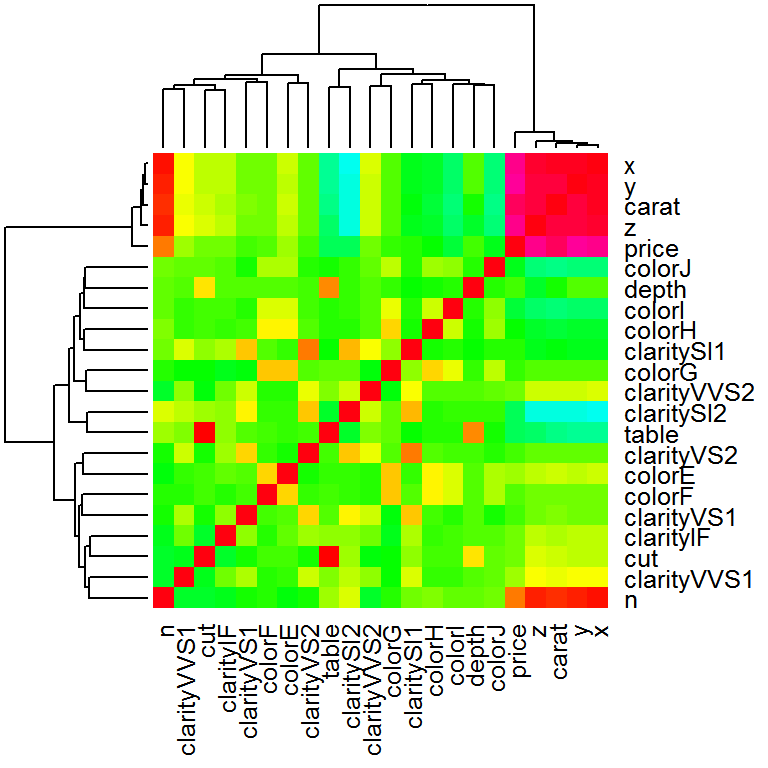

```r
cm = cor(data_clean, use = "pairwise.complete.obs")
heatmap(cm, col = rainbow(100), scale = "none")
```

```r
write.csv(cm, "Rlecture_Diamonds_cm.csv")
##    Then open "Rlecture_Diamonds_cm.csv" in Microsoft Excel (2010+):
##    Ctrl+A -> tag: Home -> Conditional Formatting -> Color Scales
```

# Data Cleaning (3b): Delete Collinear Variables

- Delete collinear variables with lower triangular of correlation matrix

```r
(collinear = apply(lower.tri(cm) & (abs(cm) > 0.95), 1, sum))
```

```
##           n       carat         cut      colorE      colorF      colorG
##           0           0           0           0           0           0
##      colorH      colorI      colorJ   clarityIF  claritySI1  claritySI2
##           0           0           0           0           0           0
##  clarityVS1  clarityVS2 clarityVVS1 clarityVVS2       depth       table
##           0           0           0           0           0           0
##       price           x           y           z
##           0           1           2           3
```

```r
data_clean = data_clean[, (names(collinear)[collinear == 0]), with = FALSE]
dim(data_clean)
```

```
## [1] 53940    19
```

# Data Cleaning (4): Fill NAs

- Check NA values

```r
data_clean[, lapply(.SD, function(x){sum(is.na(x))})]
```

```
##    n carat cut colorE colorF colorG colorH colorI colorJ clarityIF
## 1: 0     0   0      0      0      0      0      0      0         0
##    claritySI1 claritySI2 clarityVS1 clarityVS2 clarityVVS1 clarityVVS2
## 1:          0          0          0          0           0           0
##    depth table price
## 1:     0     0 14232
```

- Fill NA values with the median/mean/0/… of the column (Not necessary for predicted variable Y)

```r
fillNA = function(x){
    a = median(x, na.rm = TRUE)
    x[is.na(x) == TRUE] = a
    return(x)
}
data_clean = data_clean[, lapply(.SD, fillNA)]
```

# Data Cleaning (5): Distribution Normalization

- One method: Standardize all variables with mean 0 and standard deviation 1

```r
data_clean = data_clean[, lapply(.SD, function(x){(x - mean(x))/sd(x)})]
```

- Another method: Standardize all variables to satisfy standard normal distributioon

```r
data_clean = data_clean[, lapply(.SD, function(x){qnorm((frank(x)-0.5)/length(x))})]
```

# Lecture 5. Network Analysis

# Preparation

- Download the dataset “[Rlecture_data_facebook.txt](https://github.com/founderfan/Data-Open-Lecture)”

# Our Goals

- Learn network analysis in R with [igraph](http://kateto.net/netscix2016)
- Learn some basic concepts and methods to analyze a network
- Learn ERGM, a regression for network structure

# 5.1 Introduction to Network

# Network Analysis

- There are many kinds of networks in the society: classmates, friends, telephones, business transactions,…
- How they are same with and different from each other?
- When we want to compare them, we need to represent them in a uniform way.
- Network (graph) representation in mathematics $G = (V, E)$
- $G$ (Graph): the whole network
- $V$ (Vertex): the nodes of network (people, companies, …)
- $E$ (Edges): the connection between nodes (friendship, transactions, …)

# An R Network Analysis Package: igraph

- Install by install.packages(“igraph”)

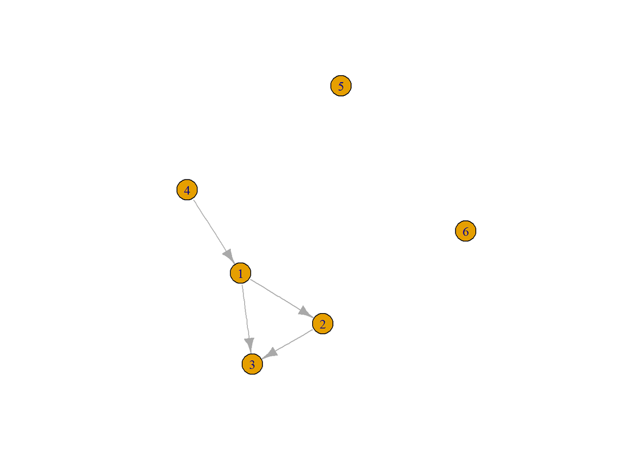

```r
library("igraph")
g = graph(edges = c(1,2, 2,3, 1,3, 4,1), n = 6)
plot(g)
```

```r
g
```

```
## IGRAPH D--- 6 4 --
## + edges:
## [1] 1->2 2->3 1->3 4->1
```

```r
V(g)
```

```
## + 6/6 vertices:
## [1] 1 2 3 4 5 6
```

```r
E(g)
```

```
## + 4/4 edges:
## [1] 1->2 2->3 1->3 4->1
```

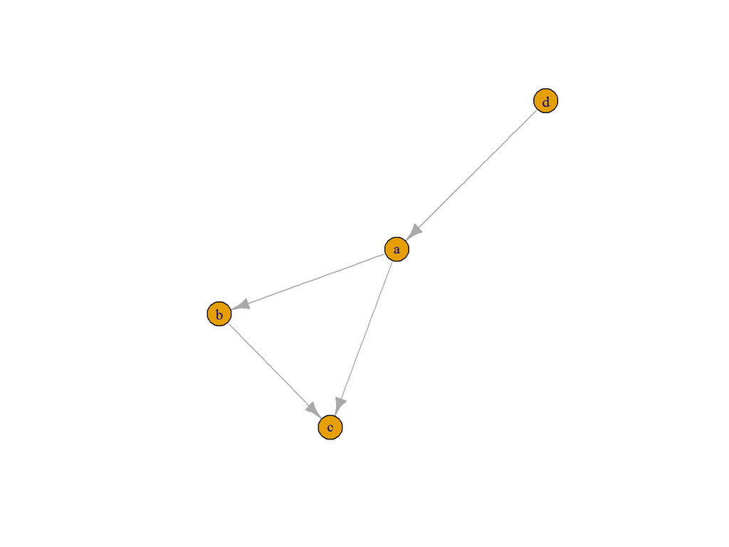

```r
g_namev = graph(edges = c("a","b", "b","c", "a","c", "d","a"))
plot(g_namev)
```

# Directed and Undirected k-Stars

- We can also create simple graphs by graph.formula()

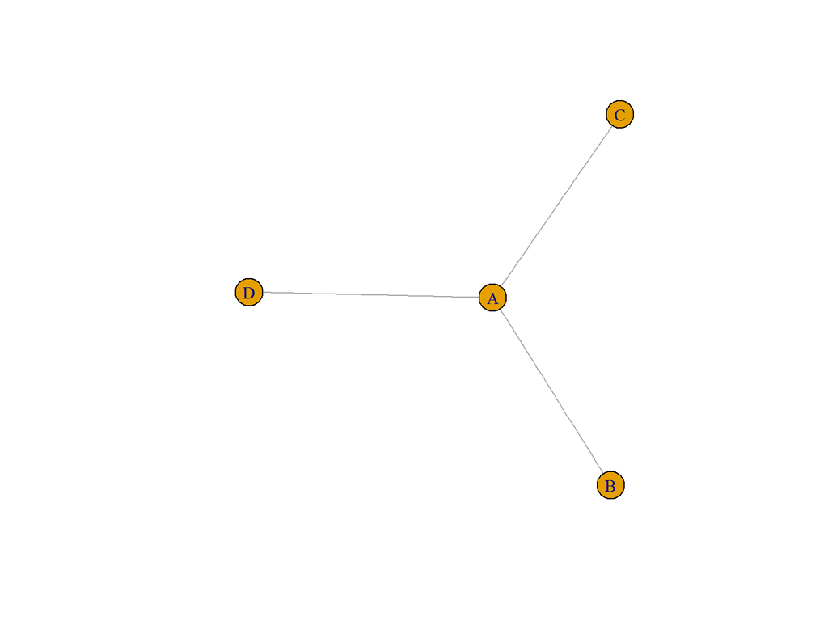

```r
g_staru = graph.formula(B:C:D - A) # Undirected 3-Stars
plot(g_staru)
```

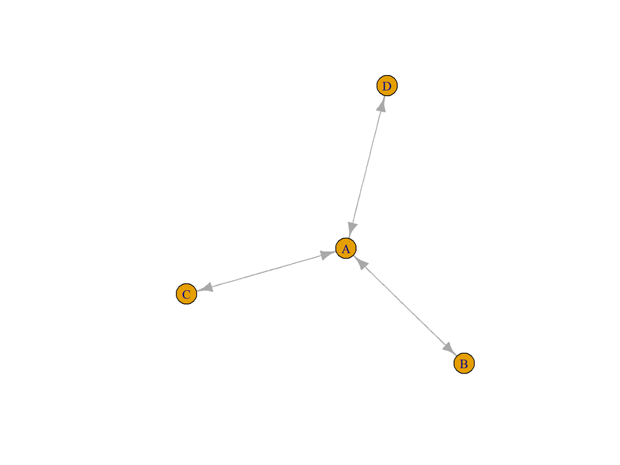

```r
g_starb = graph.formula(B:C:D + A) # Bidirectional 3-Stars
plot(g_starb)
```

- Create one-sided directed graph with “+” on one side of “-”s

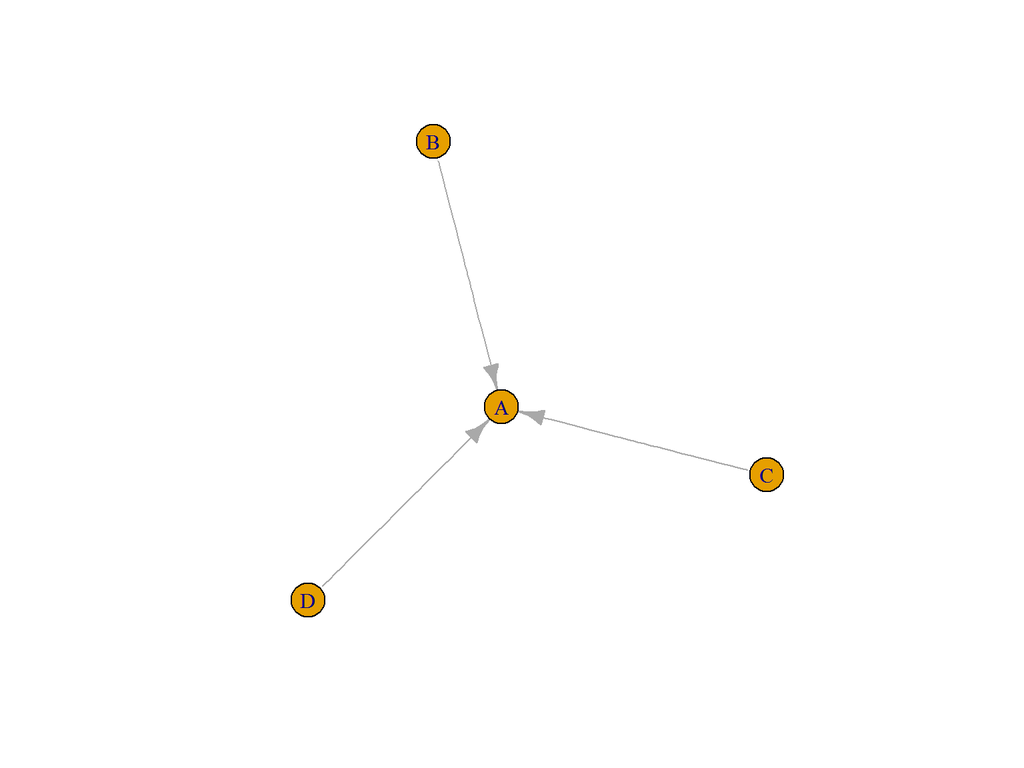

```r
g_stari = graph.formula(B:C:D ---+ A) # In-directed 3-Stars
plot(g_stari)
```

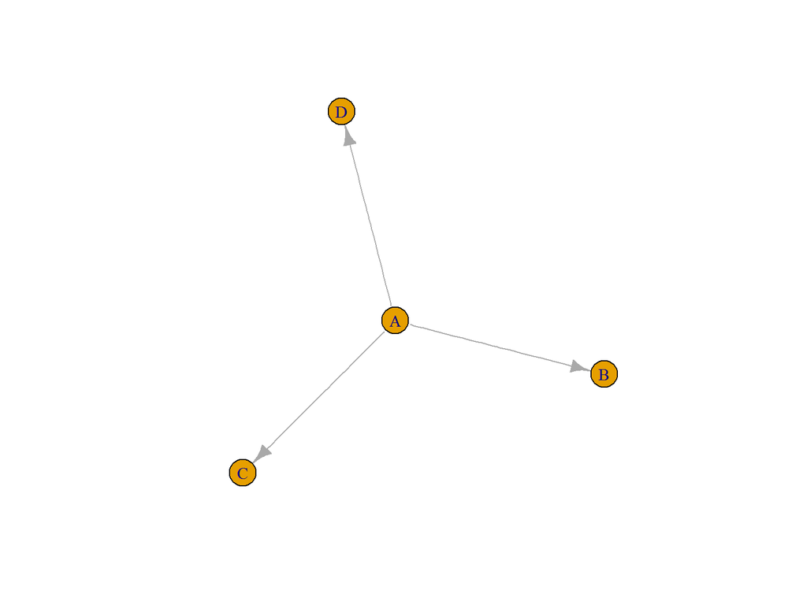

```r
g_staro = graph.formula(B:C:D +- A) # Out-directed 3-Stars
plot(g_staro)
```

# Some Other Basic Components of a Graph

- Tree graph and fully-connected graph

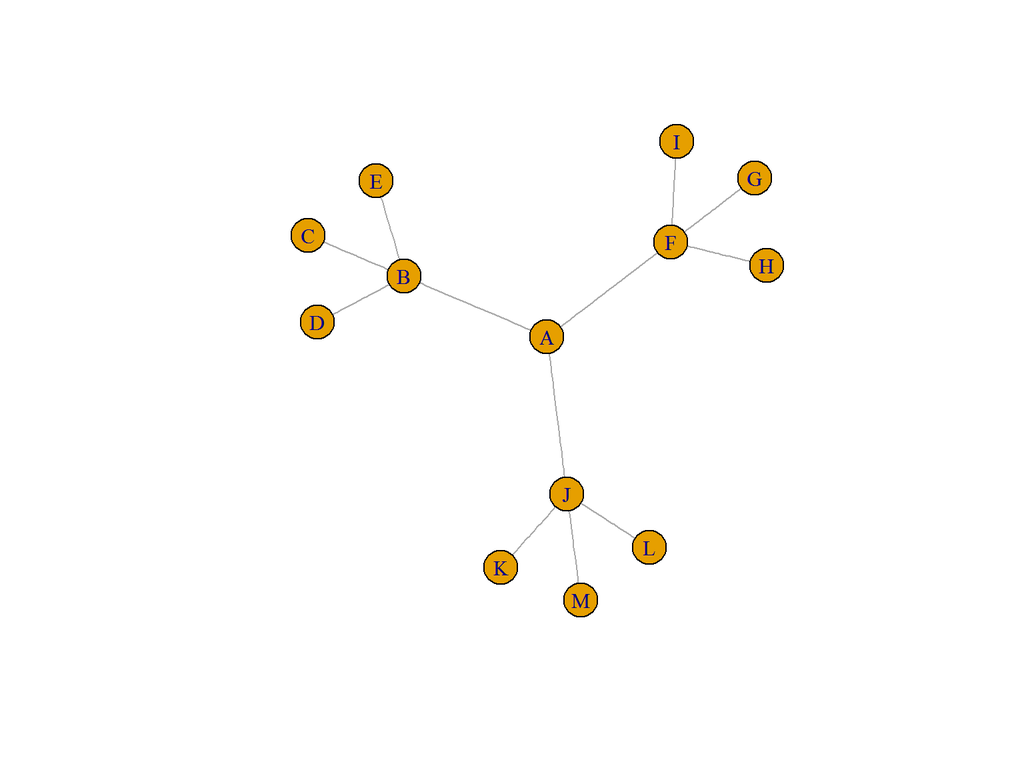

```r
g_tree = graph.formula(A - B - C:D:E, A - F - G:H:I, A - J - K:M:L) # Tree Graph
plot(g_tree)
```

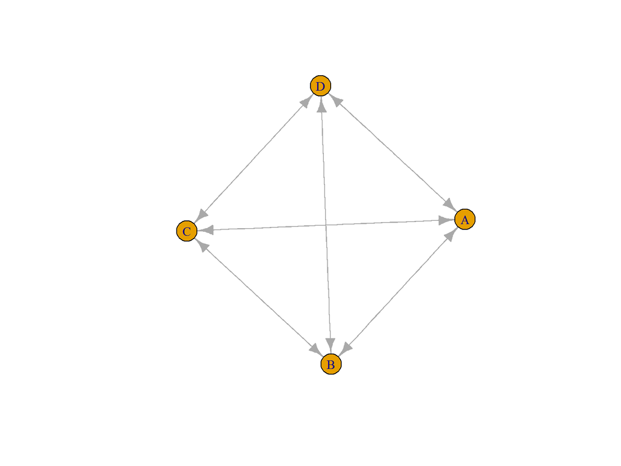

```r
g_full = graph.formula(A:B:C:D + A:B:C:D) # Fully-connected Graph
plot(g_full)
```

- Ring graph and isolated graph

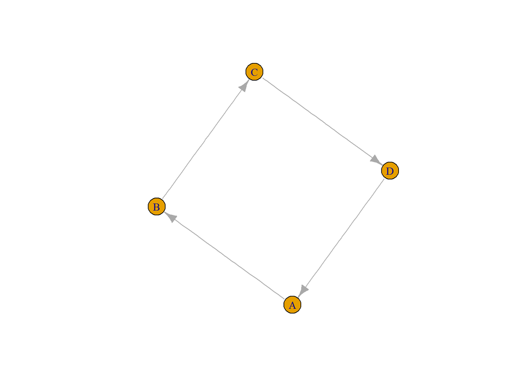

```r
g_ring = graph.formula(A -+ B -+ C -+ D -+ A) # Ring Graph
plot(g_ring)
```

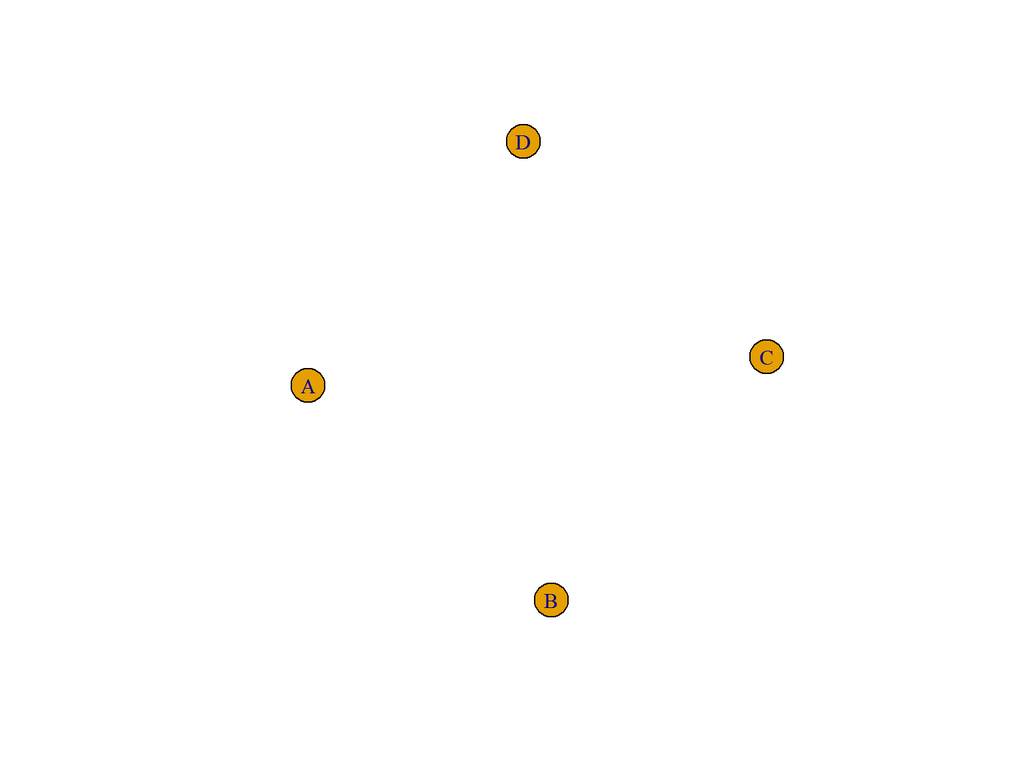

```r
g_empty = graph.formula(A:B:C:D) # Graph of Isolated Points
plot(g_empty)
```